# Data Analysis

```python
import pandas as pd
import torch
import matplotlib.pyplot as plt
import seaborn as sns
```

```python
df=pd.read_csv("latest.csv")
```

checking null values in data.

```python
df.isna().sum()
```

```
value                 0
trip_class            0
show_to_affiliates    0
origin                0
destination           0
gate                  0
depart_date           0
return_date           0
number_of_changes     0
found_at              0
duration              0
distance              0
actual                0
dtype: int64
```

Created a pairplot to know the relation of each column with other column

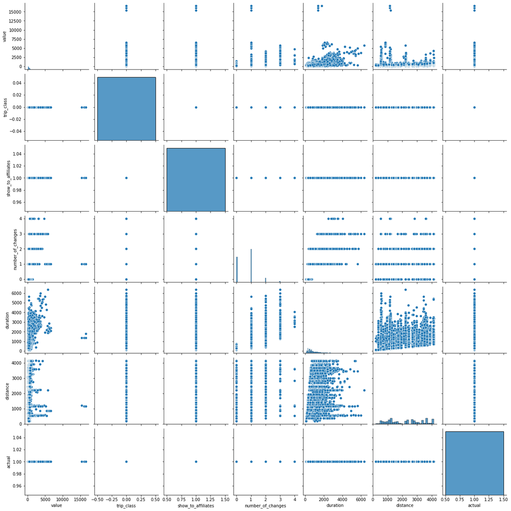

```python
sns.pairplot(data=df)
```

it can be seen that some of the labels has only single value so their data points are in single line.

let's further evaluate the data usign heathmap.

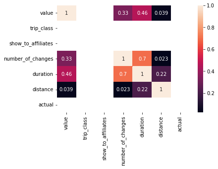

```python
sns.heatmap(df.corr(),annot=True)
```

Here, we can see that trip class, show to affiliates and actual column are blank. which means they do not have different values.

```python
df['origin'].unique()
```

```
array(['YVR', 'YMQ', 'YYC', 'YEA', 'YWG', 'ATL', 'CLT', 'NYC', 'CHI',
       'SFO', 'DFW', 'LAS', 'SEA', 'YTO'], dtype=object)
```

so from our graph evaluation. let's check the value range of trip class, show to affiliates and actual column

```python
df['show_to_affiliates'].unique()
```

```
array([ True])
```

```python
df['trip_class'].unique()
```

```
array([0])
```

```python
df['actual'].unique()
```

```
array([ True])
```

# Data Pre-Processing.

As all of them have single value. it will not be useful for our model. so, we will just drop it from dataframe.

```python
df=df.drop('show_to_affiliates',axis=1)
```

```python
df.head()
```

|  | value | trip_class | origin | destination | gate | depart_date | return_date | number_of_changes | found_at | duration | distance | actual |
| --- | --- | --- | --- | --- | --- | --- | --- | --- | --- | --- | --- | --- |
| 0 | 173 | 0 | YVR | YTO | Mytrip.com | 2022-08-08 | 2022-08-15 | 0 | 2021-11-27T01:56:03 | 570 | 3346 | True |
| 1 | 184 | 0 | YVR | YTO | Mytrip.com | 2022-03-09 | 2022-03-17 | 0 | 2021-11-25T03:41:11 | 590 | 3346 | True |
| 2 | 188 | 0 | YVR | YTO | Mytrip.com | 2022-02-01 | 2022-02-04 | 0 | 2021-11-23T16:20:14 | 590 | 3346 | True |
| 3 | 192 | 0 | YVR | YTO | Mytrip.com | 2022-01-29 | 2022-01-31 | 0 | 2021-11-27T08:04:57 | 590 | 3346 | True |
| 4 | 194 | 0 | YVR | YTO | Gotogate | 2022-01-28 | 2022-01-31 | 0 | 2021-11-27T08:16:47 | 591 | 3346 | True |

```python
df=df.drop('trip_class',axis=1)
```

```python
df=df.drop('actual',axis=1)
```

```python
df.head()
```

|  | value | origin | destination | gate | depart_date | return_date | number_of_changes | found_at | duration | distance |
| --- | --- | --- | --- | --- | --- | --- | --- | --- | --- | --- |
| 0 | 173 | YVR | YTO | Mytrip.com | 2022-08-08 | 2022-08-15 | 0 | 2021-11-27T01:56:03 | 570 | 3346 |
| 1 | 184 | YVR | YTO | Mytrip.com | 2022-03-09 | 2022-03-17 | 0 | 2021-11-25T03:41:11 | 590 | 3346 |
| 2 | 188 | YVR | YTO | Mytrip.com | 2022-02-01 | 2022-02-04 | 0 | 2021-11-23T16:20:14 | 590 | 3346 |
| 3 | 192 | YVR | YTO | Mytrip.com | 2022-01-29 | 2022-01-31 | 0 | 2021-11-27T08:04:57 | 590 | 3346 |
| 4 | 194 | YVR | YTO | Gotogate | 2022-01-28 | 2022-01-31 | 0 | 2021-11-27T08:16:47 | 591 | 3346 |

```python
df.count()
```

```
value                27339
origin               27339
destination          27339
gate                 27339
depart_date          27339
return_date          27339
number_of_changes    27339
found_at             27339
duration             27339
distance             27339
dtype: int64
```

checking duplicate values and removing them

```python
df.duplicated().sum()
```

```
12597
```

```python
df=df.drop_duplicates()
```

```python
df.duplicated().sum()
```

```
0
```

```python
df.count()
```

```
value                14742
origin               14742
destination          14742
gate                 14742
depart_date          14742
return_date          14742
number_of_changes    14742
found_at             14742
duration             14742
distance             14742
dtype: int64
```

formatting the found_at column to date.

```python
df['found_at']=df['found_at'].apply(lambda x:x[:10])
```

```python
df.info()
```

```
<class 'pandas.core.frame.DataFrame'>
Int64Index: 14742 entries, 0 to 23518
Data columns (total 10 columns):
 #   Column             Non-Null Count  Dtype
---  ------             --------------  -----
 0   value              14742 non-null  int64
 1   origin             14742 non-null  object
 2   destination        14742 non-null  object
 3   gate               14742 non-null  object
 4   depart_date        14742 non-null  object
 5   return_date        14742 non-null  object
 6   number_of_changes  14742 non-null  int64
 7   found_at           14742 non-null  object
 8   duration           14742 non-null  int64
 9   distance           14742 non-null  int64
dtypes: int64(4), object(6)
memory usage: 1.2+ MB
```

```python
df.head()
```

|  | value | origin | destination | gate | depart_date | return_date | number_of_changes | found_at | duration | distance |
| --- | --- | --- | --- | --- | --- | --- | --- | --- | --- | --- |
| 0 | 173 | YVR | YTO | Mytrip.com | 2022-08-08 | 2022-08-15 | 0 | 2021-11-27 | 570 | 3346 |
| 1 | 184 | YVR | YTO | Mytrip.com | 2022-03-09 | 2022-03-17 | 0 | 2021-11-25 | 590 | 3346 |
| 2 | 188 | YVR | YTO | Mytrip.com | 2022-02-01 | 2022-02-04 | 0 | 2021-11-23 | 590 | 3346 |
| 3 | 192 | YVR | YTO | Mytrip.com | 2022-01-29 | 2022-01-31 | 0 | 2021-11-27 | 590 | 3346 |
| 4 | 194 | YVR | YTO | Gotogate | 2022-01-28 | 2022-01-31 | 0 | 2021-11-27 | 591 | 3346 |

as we saw that the ates were in object format. so we will convert it into datetime format

```python
df['found_at']=pd.to_datetime(df['found_at'])
```

```python
df['found_at']=pd.to_datetime(df['found_at'], format='%Y%m%d', errors='coerce')
```

```python
df['return_date']=pd.to_datetime(df['return_date'])
df['return_date']=pd.to_datetime(df['return_date'],format='%Y%m%d', errors='coerce')
```

```python
df['depart_date']=pd.to_datetime(df['depart_date'])
df['depart_date']=pd.to_datetime(df['depart_date'],format='%Y%m%d', errors='coerce')
```

```python
df['days_to_departure']=df['depart_date']-df['found_at']
```

```python
df.head()
```

|  | value | origin | destination | gate | depart_date | return_date | number_of_changes | found_at | duration | distance | days_to_departure |
| --- | --- | --- | --- | --- | --- | --- | --- | --- | --- | --- | --- |
| 0 | 173 | YVR | YTO | Mytrip.com | 2022-08-08 | 2022-08-15 | 0 | 2021-11-27 | 570 | 3346 | 254 days |
| 1 | 184 | YVR | YTO | Mytrip.com | 2022-03-09 | 2022-03-17 | 0 | 2021-11-25 | 590 | 3346 | 104 days |
| 2 | 188 | YVR | YTO | Mytrip.com | 2022-02-01 | 2022-02-04 | 0 | 2021-11-23 | 590 | 3346 | 70 days |
| 3 | 192 | YVR | YTO | Mytrip.com | 2022-01-29 | 2022-01-31 | 0 | 2021-11-27 | 590 | 3346 | 63 days |
| 4 | 194 | YVR | YTO | Gotogate | 2022-01-28 | 2022-01-31 | 0 | 2021-11-27 | 591 | 3346 | 62 days |

```python
df.describe()
```

|  | value | number_of_changes | duration | distance | days_to_departure |
| --- | --- | --- | --- | --- | --- |
| count | 14742.000000 | 14742.000000 | 14742.000000 | 14742.000000 | 14742 |
| mean | 443.720798 | 0.704314 | 951.049383 | 2273.510921 | 42 days 02:34:14.212454212 |
| std | 499.428877 | 0.672470 | 708.367410 | 1151.994661 | 52 days 13:25:40.690751402 |
| min | 0.000000 | 0.000000 | 109.000000 | 193.000000 | -1 days +00:00:00 |
| 25% | 228.000000 | 0.000000 | 471.000000 | 1191.000000 | 11 days 00:00:00 |
| 50% | 349.000000 | 1.000000 | 730.000000 | 2387.000000 | 28 days 00:00:00 |
| 75% | 527.000000 | 1.000000 | 1273.000000 | 3362.000000 | 43 days 00:00:00 |
| max | 16588.000000 | 4.000000 | 6360.000000 | 4152.000000 | 358 days 00:00:00 |

```python
df.median()
```

```
value                             349
number_of_changes                   1
duration                          730
distance                         2387
days_to_departure    28 days 00:00:00
dtype: object
```

```python
df['days_to_departure']=(df['days_to_departure']).dt.days
```

```python
import numpy as np
```

labelling the column on the base of days to departure.

```python
df['action']="BUY"
df.loc[df['days_to_departure']>30,'action']='WAIT'
```

```python
df.head(100)
```

|  | value | origin | destination | gate | depart_date | return_date | number_of_changes | found_at | duration | distance | days_to_departure | action |
| --- | --- | --- | --- | --- | --- | --- | --- | --- | --- | --- | --- | --- |
| 0 | 173 | YVR | YTO | Mytrip.com | 2022-08-08 | 2022-08-15 | 0 | 2021-11-27 | 570 | 3346 | 254 | WAIT |
| 1 | 184 | YVR | YTO | Mytrip.com | 2022-03-09 | 2022-03-17 | 0 | 2021-11-25 | 590 | 3346 | 104 | WAIT |
| 2 | 188 | YVR | YTO | Mytrip.com | 2022-02-01 | 2022-02-04 | 0 | 2021-11-23 | 590 | 3346 | 70 | WAIT |
| 3 | 192 | YVR | YTO | Mytrip.com | 2022-01-29 | 2022-01-31 | 0 | 2021-11-27 | 590 | 3346 | 63 | WAIT |
| 4 | 194 | YVR | YTO | Gotogate | 2022-01-28 | 2022-01-31 | 0 | 2021-11-27 | 591 | 3346 | 62 | WAIT |
| ... | ... | ... | ... | ... | ... | ... | ... | ... | ... | ... | ... | ... |
| 95 | 329 | YYC | YTO | Thefaremasters.com | 2021-12-09 | 2021-12-11 | 0 | 2021-11-25 | 488 | 2689 | 14 | BUY |
| 96 | 330 | YYC | YTO | Kiwi.com | 2021-11-30 | 2021-12-02 | 1 | 2021-11-22 | 1041 | 2710 | 8 | BUY |
| 97 | 336 | YYC | YTO | Kiwi.com | 2021-11-29 | 2021-12-02 | 1 | 2021-11-22 | 874 | 2710 | 7 | BUY |
| 98 | 345 | YYC | YTO | Thefaremasters.com | 2021-12-02 | 2021-12-04 | 0 | 2021-11-24 | 489 | 2689 | 8 | BUY |
| 99 | 355 | YYC | YTO | Trip.com | 2021-12-14 | 2021-12-16 | 1 | 2021-11-22 | 1553 | 2710 | 22 | BUY |

100 rows × 12 columns

```python
df['action']=df['action'].map({"BUY":1,"WAIT":0})
```

```python
df.head()
```

|  | value | origin | destination | gate | depart_date | return_date | number_of_changes | found_at | duration | distance | days_to_departure | action |
| --- | --- | --- | --- | --- | --- | --- | --- | --- | --- | --- | --- | --- |
| 0 | 173 | YVR | YTO | Mytrip.com | 2022-08-08 | 2022-08-15 | 0 | 2021-11-27 | 570 | 3346 | 254 | 0 |
| 1 | 184 | YVR | YTO | Mytrip.com | 2022-03-09 | 2022-03-17 | 0 | 2021-11-25 | 590 | 3346 | 104 | 0 |
| 2 | 188 | YVR | YTO | Mytrip.com | 2022-02-01 | 2022-02-04 | 0 | 2021-11-23 | 590 | 3346 | 70 | 0 |
| 3 | 192 | YVR | YTO | Mytrip.com | 2022-01-29 | 2022-01-31 | 0 | 2021-11-27 | 590 | 3346 | 63 | 0 |
| 4 | 194 | YVR | YTO | Gotogate | 2022-01-28 | 2022-01-31 | 0 | 2021-11-27 | 591 | 3346 | 62 | 0 |

getting the days to return from found date and return date.

```python
df['days_to_return']=df['return_date']-df['found_at']
```

```python
df['days_to_return']=(df['days_to_return']).dt.days
```

```python
df=df.drop('depart_date',axis=1)
df=df.drop('return_date',axis=1)
```

```python
df.head()
```

|  | value | origin | destination | gate | number_of_changes | found_at | duration | distance | days_to_departure | action | days_to_return |
| --- | --- | --- | --- | --- | --- | --- | --- | --- | --- | --- | --- |
| 0 | 173 | YVR | YTO | Mytrip.com | 0 | 2021-11-27 | 570 | 3346 | 254 | 0 | 261 |
| 1 | 184 | YVR | YTO | Mytrip.com | 0 | 2021-11-25 | 590 | 3346 | 104 | 0 | 112 |
| 2 | 188 | YVR | YTO | Mytrip.com | 0 | 2021-11-23 | 590 | 3346 | 70 | 0 | 73 |
| 3 | 192 | YVR | YTO | Mytrip.com | 0 | 2021-11-27 | 590 | 3346 | 63 | 0 | 65 |
| 4 | 194 | YVR | YTO | Gotogate | 0 | 2021-11-27 | 591 | 3346 | 62 | 0 | 65 |

As we converted depart date and return date to days to departure and days to return we now only have to format found_at date so we can use it for our model.

```python
df['found_at_year'] = df['found_at'].dt.year
```

```python
df['found_at_month'] = df['found_at'].dt.month
```

```python
df['found_at_day'] = df['found_at'].dt.day
```

```python
df = df.drop('found_at',axis=1)
```

```python
df.head()
```

|  | value | origin | destination | gate | number_of_changes | duration | distance | days_to_departure | action | days_to_return | found_at_year | found_at_month | found_at_day |
| --- | --- | --- | --- | --- | --- | --- | --- | --- | --- | --- | --- | --- | --- |
| 0 | 173 | YVR | YTO | Mytrip.com | 0 | 570 | 3346 | 254 | 0 | 261 | 2021 | 11 | 27 |
| 1 | 184 | YVR | YTO | Mytrip.com | 0 | 590 | 3346 | 104 | 0 | 112 | 2021 | 11 | 25 |
| 2 | 188 | YVR | YTO | Mytrip.com | 0 | 590 | 3346 | 70 | 0 | 73 | 2021 | 11 | 23 |
| 3 | 192 | YVR | YTO | Mytrip.com | 0 | 590 | 3346 | 63 | 0 | 65 | 2021 | 11 | 27 |
| 4 | 194 | YVR | YTO | Gotogate | 0 | 591 | 3346 | 62 | 0 | 65 | 2021 | 11 | 27 |

```python
df['gate'].nunique()
```

```
42
```

oe-hot encoding the gate column

```python
dummy = pd.get_dummies(df['origin'],prefix="origin",drop_first=True)
df = pd.concat([df,dummy],axis=1)
df = df.drop('origin', axis=1)
```

```python
dummy = pd.get_dummies(df['destination'],prefix='destination',drop_first=True)
df = pd.concat([df,dummy],axis=1)
df = df.drop('destination',axis=1)
```

```python
dummy = pd.get_dummies(df['gate'],prefix='gate',drop_first=True)
df = pd.concat([df,dummy],axis=1)
df = df.drop('gate',axis=1)
```

```python
df.head()
```

|  | value | number_of_changes | duration | distance | days_to_departure | action | days_to_return | found_at_year | found_at_month | found_at_day | origin_CHI | origin_CLT | origin_DFW | origin_LAS | origin_NYC | origin_SEA | origin_SFO | origin_YEA | origin_YMQ | origin_YTO | origin_YVR | origin_YWG | origin_YYC | destination_CHI | destination_CLT | destination_DFW | destination_LAS | destination_NYC | destination_SEA | … |
| --- | --- | --- | --- | --- | --- | --- | --- | --- | --- | --- | --- | --- | --- | --- | --- | --- | --- | --- | --- | --- | --- | --- | --- | --- | --- | --- | --- | --- | --- | --- |
| 0 | 173 | 0 | 570 | 3346 | 254 | 0 | 261 | 2021 | 11 | 27 | 0 | 0 | 0 | 0 | 0 | 0 | 0 | 0 | 0 | 0 | 1 | 0 | 0 | 0 | 0 | 0 | 0 | 0 | 0 | … |
| 1 | 184 | 0 | 590 | 3346 | 104 | 0 | 112 | 2021 | 11 | 25 | 0 | 0 | 0 | 0 | 0 | 0 | 0 | 0 | 0 | 0 | 1 | 0 | 0 | 0 | 0 | 0 | 0 | 0 | 0 | … |
| 2 | 188 | 0 | 590 | 3346 | 70 | 0 | 73 | 2021 | 11 | 23 | 0 | 0 | 0 | 0 | 0 | 0 | 0 | 0 | 0 | 0 | 1 | 0 | 0 | 0 | 0 | 0 | 0 | 0 | 0 | … |
| 3 | 192 | 0 | 590 | 3346 | 63 | 0 | 65 | 2021 | 11 | 27 | 0 | 0 | 0 | 0 | 0 | 0 | 0 | 0 | 0 | 0 | 1 | 0 | 0 | 0 | 0 | 0 | 0 | 0 | 0 | … |
| 4 | 194 | 0 | 591 | 3346 | 62 | 0 | 65 | 2021 | 11 | 27 | 0 | 0 | 0 | 0 | 0 | 0 | 0 | 0 | 0 | 0 | 1 | 0 | 0 | 0 | 0 | 0 | 0 | 0 | 0 | … |

```python
df.info()
```

```
<class 'pandas.core.frame.DataFrame'>
Int64Index: 14742 entries, 0 to 23518
Data columns (total 77 columns):
 #   Column                   Non-Null Count  Dtype
---  ------                   --------------  -----
 0   value                    14742 non-null  int64
 1   number_of_changes        14742 non-null  int64
 2   duration                 14742 non-null  int64
 3   distance                 14742 non-null  int64
 4   days_to_departure        14742 non-null  int64
 5   action                   14742 non-null  int64
 6   days_to_return           14742 non-null  int64
 7   found_at_year            14742 non-null  int64
 8   found_at_month           14742 non-null  int64
 9   found_at_day             14742 non-null  int64
```

[output cut: 69 more lines]

# Test Train Split.

```python
from sklearn.model_selection import train_test_split
```

```python
X = df.drop('action',axis=1)
y = df['action']
```

```python
X_train, X_test, y_train, y_test = train_test_split(X, y, test_size=0.2, random_state=101)
```

# Model Training and Evaluation

Dummy classifier as our baseline model.

```python
import numpy as np
from sklearn.dummy import DummyClassifier
from sklearn.metrics import classification_report

dummy_clf = DummyClassifier(strategy="most_frequent")
dummy_clf.fit(X_train, y_train)

y_pred_dummy = dummy_clf.predict(X_test)

dummy_clf.score(X_test, y_test)
```

```
0.5452695829094608
```

```python
np.unique(y_pred_dummy)
```

```
array([1])
```

as we can see that dummy classifier was not good at classifying the data. it only classified every data action as 1.

evaluation using classification report.

```python
print(classification_report(y_test,y_pred_dummy))
```

```
              precision    recall  f1-score   support

           0       0.00      0.00      0.00      1341
           1       0.55      1.00      0.71      1608

    accuracy                           0.55      2949
   macro avg       0.27      0.50      0.35      2949
weighted avg       0.30      0.55      0.38      2949
```

```python
X_train.shape
```

```
(11793, 76)
```

CNN model

```python
from keras import optimizers
from keras.models import Sequential, Model
from keras.layers.convolutional import Conv1D, MaxPooling1D
from keras.layers import Dense, LSTM, RepeatVector, TimeDistributed, Flatten
```

```python
model_cnn = Sequential()
model_cnn.add(Conv1D(filters=64, kernel_size=(2), activation='relu', input_shape=(76,1)))
model_cnn.add(MaxPooling1D(pool_size=2))
model_cnn.add(Flatten())
model_cnn.add(Dense(50, activation='relu'))
model_cnn.add(Dense(1))
model_cnn.compile(loss='mse', optimizer='adam', metrics=['accuracy'])
model_cnn.summary()
```

```
Model: "sequential"
_________________________________________________________________
 Layer (type)                Output Shape              Param #
=================================================================
 conv1d (Conv1D)             (None, 75, 64)            192

 max_pooling1d (MaxPooling1D  (None, 37, 64)           0
 )

 flatten (Flatten)           (None, 2368)              0

 dense (Dense)               (None, 50)                118450

 dense_1 (Dense)             (None, 1)                 51

=================================================================
Total params: 118,693
Trainable params: 118,693
Non-trainable params: 0
_________________________________________________________________
```

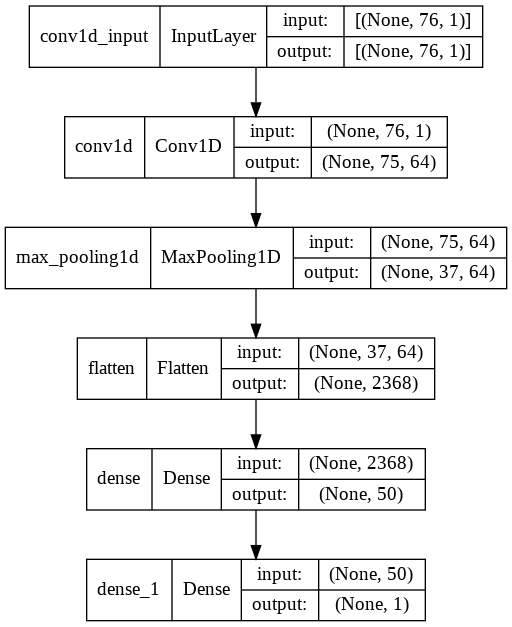

```python
from keras.utils.vis_utils import plot_model
plot_model(model_cnn, show_shapes=True, show_layer_names=True)
```

```python
model_cnn.fit(X_train, y_train, validation_data=(X_train, y_train), epochs=10, verbose=2)
```

```
369/369 - 4s - loss: 108.2207 - accuracy: 0.4749 - val_loss: 2.1716 - val_accuracy: 0.5898 - 4s/epoch - 11ms/step
369/369 - 3s - loss: 7.3687 - accuracy: 0.5513 - val_loss: 1.1505 - val_accuracy: 0.5813 - 3s/epoch - 9ms/step
369/369 - 3s - loss: 8.1550 - accuracy: 0.5706 - val_loss: 0.5036 - val_accuracy: 0.6392 - 3s/epoch - 7ms/step
369/369 - 3s - loss: 0.9594 - accuracy: 0.6173 - val_loss: 0.2063 - val_accuracy: 0.7550 - 3s/epoch - 8ms/step
369/369 - 3s - loss: 1.3463 - accuracy: 0.6330 - val_loss: 1.8889 - val_accuracy: 0.6980 - 3s/epoch - 9ms/step
369/369 - 3s - loss: 62.6228 - accuracy: 0.5556 - val_loss: 7.5570 - val_accuracy: 0.5250 - 3s/epoch - 9ms/step
369/369 - 3s - loss: 3.5819 - accuracy: 0.5814 - val_loss: 0.8455 - val_accuracy: 0.5654 - 3s/epoch - 9ms/step
369/369 - 3s - loss: 0.6022 - accuracy: 0.6268 - val_loss: 0.5752 - val_accuracy: 0.6088 - 3s/epoch - 7ms/step
369/369 - 3s - loss: 0.4748 - accuracy: 0.6427 - val_loss: 0.3361 - val_accuracy: 0.6969 - 3s/epoch - 7ms/step
369/369 - 3s - loss: 0.4341 - accuracy: 0.6353 - val_loss: 0.3709 - val_accuracy: 0.6417 - 3s/epoch - 9ms/step
```

```
<keras.callbacks.History at 0x7fb9c246c410>
```

```python
result = model_cnn.evaluate(X_test, y_test, verbose=0)
print('Test Loss:', result)
```

```
Test Loss: [0.3835991621017456, 0.6286876797676086]
```

```python
y_pred = model_cnn.predict(X_test)
y_pred_cnn = (y_pred > 0.5).astype("int32")
print(classification_report(y_test,y_pred_cnn))
```

```
              precision    recall  f1-score   support

           0       0.56      0.84      0.67      1341
           1       0.77      0.45      0.57      1608

    accuracy                           0.63      2949
   macro avg       0.67      0.65      0.62      2949
weighted avg       0.68      0.63      0.62      2949
```

SVM model

```python
from sklearn.svm import SVC
from sklearn import metrics
svc=SVC(kernel = "rbf")
svc.fit(X_train,y_train)
y_pred=svc.predict(X_test)
print('Accuracy Score:')
print(metrics.accuracy_score(y_test,y_pred))
```

```
Accuracy Score:
0.8067141403865717
```

```python
y_pred_svc = svc.predict(X_test)
print(classification_report(y_test,y_pred_svc))
```

```
              precision    recall  f1-score   support

           0       0.94      0.62      0.74      1341
           1       0.75      0.97      0.85      1608

    accuracy                           0.81      2949
   macro avg       0.84      0.79      0.79      2949
weighted avg       0.84      0.81      0.80      2949
```

# Model Perfomance Comparison

Now we will compare the perfomance of Dummy Classifier, CNN and SVM using the accuracy, precision, Recall and f1-score evaluation metrics.

```python
from sklearn.metrics import accuracy_score
from sklearn.metrics import recall_score
from sklearn.metrics import f1_score
from sklearn.metrics import precision_score

dummy_accuracy = accuracy_score(y_test, y_pred_dummy)
dummy_precision = precision_score(y_test, y_pred_dummy, average='binary')
dummy_f1 = f1_score(y_test, y_pred_dummy, average='binary')
dummy_recall = recall_score(y_test, y_pred_dummy, average='binary')

cnn_accuracy = accuracy_score(y_test, y_pred_cnn)
cnn_precision = precision_score(y_test, y_pred_cnn, average='binary')
cnn_f1 = f1_score(y_test, y_pred_cnn, average='binary')
cnn_recall = recall_score(y_test, y_pred_cnn, average='binary')

svm_accuracy = accuracy_score(y_test, y_pred_svc)
svm_precision = precision_score(y_test, y_pred_svc, average='binary')
svm_f1 = f1_score(y_test, y_pred_svc, average='binary')
svm_recall = recall_score(y_test, y_pred_svc, average='binary')
```

Ploting the different evaluation score

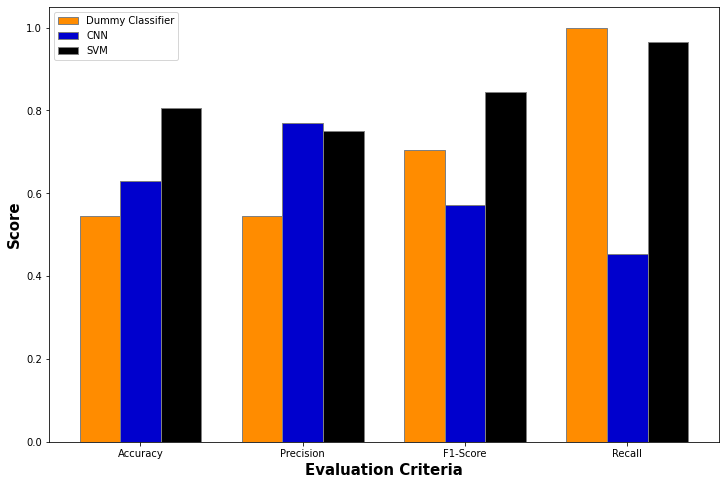

```python
barWidth = 0.25
fig = plt.subplots(figsize =(12, 8))

dummy_score = [dummy_accuracy,dummy_precision,dummy_f1,dummy_recall]
cnn_score = [cnn_accuracy,cnn_precision,cnn_f1,cnn_recall]
svm_score = [svm_accuracy,svm_precision,svm_f1,svm_recall]

br1 = np.arange(len(dummy_score))
br2 = [x + barWidth for x in br1]
br3 = [x + barWidth for x in br2]

plt.bar(br1, dummy_score, color ='darkorange', width = barWidth,
        edgecolor ='grey', label ='Dummy Classifier')
plt.bar(br2, cnn_score, color ='mediumblue', width = barWidth,
        edgecolor ='grey', label ='CNN')
plt.bar(br3, svm_score, color ='k', width = barWidth,
        edgecolor ='grey', label ='SVM')

plt.xlabel('Evaluation Criteria', fontweight ='bold', fontsize = 15)
plt.ylabel('Score', fontweight ='bold', fontsize = 15)
plt.xticks([r + barWidth for r in range(len(dummy_score))],
        ['Accuracy', 'Precision', 'F1-Score', 'Recall'])

plt.legend()
plt.show()
```